# Explore Amazon Products Sale 2023 dataset with Python

## 1. Import then combined all data into 1 dataframe

```python
!pip install opendatasets --upgrade

import opendatasets as od
dataset_url = ('https://www.kaggle.com/datasets/lokeshparab/amazon-products-dataset')
od.download('https://www.kaggle.com/datasets/lokeshparab/amazon-products-dataset')
```

```
Skipping, found downloaded files in ".\amazon-products-dataset" (use force=True to force download)
```

```python
datadir = 'amazon-products-dataset'
import os
all_files = os.listdir(datadir)
```

```python
import pandas as pd
import numpy as np
import matplotlib.pyplot as plt
import seaborn as sns
```

```python
import glob

path = 'amazon-products-dataset'
all_files = glob.glob(path + "/*.csv")
```

```python
dfs = []
```

```python
for file in all_files:
    df = pd.read_csv(file, index_col=None, header=0)
    dfs.append(df)
```

```python
amazon_df = pd.concat(dfs, axis=0, ignore_index=True)
```

```python
amazon_df.info()
```

```
<class 'pandas.core.frame.DataFrame'>
RangeIndex: 1103170 entries, 0 to 1103169
Data columns (total 10 columns):
 #   Column          Non-Null Count    Dtype
---  ------          --------------    -----
 0   name            1103170 non-null  object
 1   main_category   1103170 non-null  object
 2   sub_category    1103170 non-null  object
 3   image           1103170 non-null  object
 4   link            1103170 non-null  object
 5   ratings         751582 non-null   object
 6   no_of_ratings   751582 non-null   object
 7   discount_price  980844 non-null   object
 8   actual_price    1067544 non-null  object
 9   Unnamed: 0      551585 non-null   float64
dtypes: float64(1), object(9)
memory usage: 84.2+ MB
```

## 2. Cleaning the data

```python
amazon_df.head(5)
```

|  | name | main_category | sub_category | image | link | ratings | no_of_ratings | discount_price | actual_price | Unnamed: 0 |
| --- | --- | --- | --- | --- | --- | --- | --- | --- | --- | --- |
| 0 | Lloyd 1.5 Ton 3 Star Inverter Split Ac (5 In 1... | appliances | Air Conditioners | https://m.media-amazon.com/images/I/31UISB90sY... | https://www.amazon.in/Lloyd-Inverter-Convertib... | 4.2 | 2,255 | ₹32,999 | ₹58,990 | NaN |
| 1 | LG 1.5 Ton 5 Star AI DUAL Inverter Split AC (C... | appliances | Air Conditioners | https://m.media-amazon.com/images/I/51JFb7FctD... | https://www.amazon.in/LG-Convertible-Anti-Viru... | 4.2 | 2,948 | ₹46,490 | ₹75,990 | NaN |
| 2 | LG 1 Ton 4 Star Ai Dual Inverter Split Ac (Cop... | appliances | Air Conditioners | https://m.media-amazon.com/images/I/51JFb7FctD... | https://www.amazon.in/LG-Inverter-Convertible-... | 4.2 | 1,206 | ₹34,490 | ₹61,990 | NaN |
| 3 | LG 1.5 Ton 3 Star AI DUAL Inverter Split AC (C... | appliances | Air Conditioners | https://m.media-amazon.com/images/I/51JFb7FctD... | https://www.amazon.in/LG-Convertible-Anti-Viru... | 4.0 | 69 | ₹37,990 | ₹68,990 | NaN |
| 4 | Carrier 1.5 Ton 3 Star Inverter Split AC (Copp... | appliances | Air Conditioners | https://m.media-amazon.com/images/I/41lrtqXPiW... | https://www.amazon.in/Carrier-Inverter-Split-C... | 4.1 | 630 | ₹34,490 | ₹67,790 | NaN |

```python
amazon_df.info()
```

```
<class 'pandas.core.frame.DataFrame'>
RangeIndex: 1103170 entries, 0 to 1103169
Data columns (total 10 columns):
 #   Column          Non-Null Count    Dtype
---  ------          --------------    -----
 0   name            1103170 non-null  object
 1   main_category   1103170 non-null  object
 2   sub_category    1103170 non-null  object
 3   image           1103170 non-null  object
 4   link            1103170 non-null  object
 5   ratings         751582 non-null   object
 6   no_of_ratings   751582 non-null   object
 7   discount_price  980844 non-null   object
 8   actual_price    1067544 non-null  object
 9   Unnamed: 0      551585 non-null   float64
dtypes: float64(1), object(9)
memory usage: 84.2+ MB
```

```python
amazon_df.describe()
```

|  | Unnamed: 0 |
| --- | --- |
| count | 551585.000000 |
| mean | 7006.200471 |
| std | 5740.835523 |
| min | 0.000000 |
| 25% | 1550.000000 |
| 50% | 5933.000000 |
| 75% | 11482.000000 |
| max | 19199.000000 |

```python
amazon_df.isna().sum()
```

```
name                   0
main_category          0
sub_category           0
image                  0
link                   0
ratings           351588
no_of_ratings     351588
discount_price    122326
actual_price       35626
Unnamed: 0        551585
dtype: int64
```

```python
amazon_df.isna().sum().sum()
```

```
1412713
```

```python
amazon_df.duplicated().sum()
```

```
0
```

### Conclude:

1. Null values: 1412713
   - ratings 351588
   - no_of_ratings 351588
   - discount_price 122326
   - actual_price 35626
2. Duplicated values: 0
3. Unknow column: `Unnamed: 0`
4. Incorrect datatype columns:
   - `ratings`: object
   - `no_of_ratings`: object
   - `discount_price`: object
   - `actual_price`: object

### a. First I delete all the rows with null values

```python
amazon_df = amazon_df.dropna()
```

```python
amazon_df.to_csv('cleaned_data.csv', index=False)
```

```python
amazon_df = amazon_df.reset_index(drop=True)
```

```python
amazon_df.info()
```

```
<class 'pandas.core.frame.DataFrame'>
RangeIndex: 340680 entries, 0 to 340679
Data columns (total 10 columns):
 #   Column          Non-Null Count   Dtype
---  ------          --------------   -----
 0   name            340680 non-null  object
 1   main_category   340680 non-null  object
 2   sub_category    340680 non-null  object
 3   image           340680 non-null  object
 4   link            340680 non-null  object
 5   ratings         340680 non-null  object
 6   no_of_ratings   340680 non-null  object
 7   discount_price  340680 non-null  object
 8   actual_price    340680 non-null  object
 9   Unnamed: 0      340680 non-null  float64
dtypes: float64(1), object(9)
memory usage: 26.0+ MB
```

```python
amazon_df
```

|  | name | main_category | sub_category | image | link | ratings | no_of_ratings | discount_price | actual_price | Unnamed: 0 |
| --- | --- | --- | --- | --- | --- | --- | --- | --- | --- | --- |
| 0 | Lloyd 1.5 Ton 3 Star Inverter Split Ac (5 In 1... | appliances | Air Conditioners | https://m.media-amazon.com/images/I/31UISB90sY... | https://www.amazon.in/Lloyd-Inverter-Convertib... | 4.2 | 2,255 | ₹32,999 | ₹58,990 | 0.0 |
| 1 | LG 1.5 Ton 5 Star AI DUAL Inverter Split AC (C... | appliances | Air Conditioners | https://m.media-amazon.com/images/I/51JFb7FctD... | https://www.amazon.in/LG-Convertible-Anti-Viru... | 4.2 | 2,948 | ₹46,490 | ₹75,990 | 1.0 |
| 2 | LG 1 Ton 4 Star Ai Dual Inverter Split Ac (Cop... | appliances | Air Conditioners | https://m.media-amazon.com/images/I/51JFb7FctD... | https://www.amazon.in/LG-Inverter-Convertible-... | 4.2 | 1,206 | ₹34,490 | ₹61,990 | 2.0 |
| 3 | LG 1.5 Ton 3 Star AI DUAL Inverter Split AC (C... | appliances | Air Conditioners | https://m.media-amazon.com/images/I/51JFb7FctD... | https://www.amazon.in/LG-Convertible-Anti-Viru... | 4.0 | 69 | ₹37,990 | ₹68,990 | 3.0 |
| 4 | Carrier 1.5 Ton 3 Star Inverter Split AC (Copp... | appliances | Air Conditioners | https://m.media-amazon.com/images/I/41lrtqXPiW... | https://www.amazon.in/Carrier-Inverter-Split-C... | 4.1 | 630 | ₹34,490 | ₹67,790 | 4.0 |
| ... | ... | ... | ... | ... | ... | ... | ... | ... | ... | ... |
| 340675 | BE SAVAGE Pink I Purple You Hoodie Suitable fo... | sports & fitness | Yoga | https://m.media-amazon.com/images/I/61voQ68VuT... | https://www.amazon.in/Be-savage-Purple-Hoodie-... | 4.6 | 6 | ₹711 | ₹999 | 1098.0 |
| 340676 | Adidas Regular Fit Men's Track Tops | sports & fitness | Yoga | https://m.media-amazon.com/images/I/71tHAR9pIY... | https://www.amazon.in/Adidas-Regular-Mens-Trac... | 3.2 | 9 | ₹3,449 | ₹4,599 | 1099.0 |
| 340677 | Redwolf Noice Toit Smort - Hoodie (Black) | sports & fitness | Yoga | https://m.media-amazon.com/images/I/41pKrMZ5lQ... | https://www.amazon.in/Redwolf-Noice-Smort-Cott... | 2.0 | 2 | ₹1,199 | ₹1,999 | 1100.0 |
| 340678 | Redwolf Schrute Farms B&B - Hoodie (Navy Blue) | sports & fitness | Yoga | https://m.media-amazon.com/images/I/41n9u+zNSc... | https://www.amazon.in/Redwolf-Schrute-Farms-Ho... | 4.0 | 1 | ₹1,199 | ₹1,999 | 1101.0 |
| 340679 | Mothercare Printed Cotton Elastane Girls Infan... | sports & fitness | Yoga | https://m.media-amazon.com/images/I/814X-sI3DB... | https://www.amazon.in/Mothercare-Carrot-Regula... | 4.6 | 5 | ₹1,039 | ₹1,299 | 1103.0 |

340680 rows × 10 columns

### b. Change the datatypes

- ratings: float
- no_of_ratings: int
- discount_price: float
- actual_price: float

```python
amazon_df.ratings.unique()
```

```
array(['4.2', '4.0', '4.1', '4.3', '3.9', '3.8', '3.5', '4.6', '3.3',
       '3.4', '3.7', '2.9', '5.0', '4.4', '3.6', '2.7', '4.5', '3.0',
       '3.1', '4.8', '4.7', '3.2', '2.5', '1.0', '2.6', '2.8', '1.7',
       'Get', '1.8', '2.4', '4.9', '2.2', '1.6', '1.9', '2.3', '2.0',
       '1.4', '2.1', 'FREE', '1.2', '1.3', '1.5', '₹65', '1.1', '₹70',
       '₹100', '₹99', '₹2.99'], dtype=object)
```

We can see there a few values that not appropriate.

```python
amazon_df = amazon_df[~amazon_df['ratings'].isin(['Get','FREE', '₹65', '₹70', '₹100', '₹99', '₹2.99'])]
```

```python
amazon_df.ratings.unique()
```

```
array(['4.2', '4.0', '4.1', '4.3', '3.9', '3.8', '3.5', '4.6', '3.3',
       '3.4', '3.7', '2.9', '5.0', '4.4', '3.6', '2.7', '4.5', '3.0',
       '3.1', '4.8', '4.7', '3.2', '2.5', '1.0', '2.6', '2.8', '1.7',
       '1.8', '2.4', '4.9', '2.2', '1.6', '1.9', '2.3', '2.0', '1.4',
       '2.1', '1.2', '1.3', '1.5', '1.1'], dtype=object)
```

```python
amazon_df['ratings'] = amazon_df['ratings'].astype(float)
```

```python
amazon_df['no_of_ratings'] = amazon_df['no_of_ratings'].str.replace(',', '').astype(float)
```

```python
amazon_df['no_of_ratings'] = amazon_df['no_of_ratings'].astype(int)
```

Column `discount_price` and `actual_price` have symbol ₹, so I need to remove it.

```python
amazon_df['actual_price'] = amazon_df['actual_price'].str.replace('₹', '').str.replace(',', '').astype(float)
```

```python
amazon_df['discount_price'] = amazon_df['discount_price'].str.replace('₹', '').str.replace(',', '').astype(float)
```

```python
amazon_df.info()
```

```
<class 'pandas.core.frame.DataFrame'>
Int64Index: 334963 entries, 0 to 340679
Data columns (total 10 columns):
 #   Column          Non-Null Count   Dtype
---  ------          --------------   -----
 0   name            334963 non-null  object
 1   main_category   334963 non-null  object
 2   sub_category    334963 non-null  object
 3   image           334963 non-null  object
 4   link            334963 non-null  object
 5   ratings         334963 non-null  float64
 6   no_of_ratings   334963 non-null  int32
 7   discount_price  334963 non-null  float64
 8   actual_price    334963 non-null  float64
 9   Unnamed: 0      334963 non-null  float64
dtypes: float64(4), int32(1), object(5)
memory usage: 26.8+ MB
```

#### Now let's remove the `Unnamed: 0` column

```python
amazon_df = amazon_df.drop('Unnamed: 0', axis=1)
```

```python
amazon_df
```

|  | name | main_category | sub_category | image | link | ratings | no_of_ratings | discount_price | actual_price |
| --- | --- | --- | --- | --- | --- | --- | --- | --- | --- |
| 0 | Lloyd 1.5 Ton 3 Star Inverter Split Ac (5 In 1... | appliances | Air Conditioners | https://m.media-amazon.com/images/I/31UISB90sY... | https://www.amazon.in/Lloyd-Inverter-Convertib... | 4.2 | 2255 | 32999.0 | 58990.0 |
| 1 | LG 1.5 Ton 5 Star AI DUAL Inverter Split AC (C... | appliances | Air Conditioners | https://m.media-amazon.com/images/I/51JFb7FctD... | https://www.amazon.in/LG-Convertible-Anti-Viru... | 4.2 | 2948 | 46490.0 | 75990.0 |
| 2 | LG 1 Ton 4 Star Ai Dual Inverter Split Ac (Cop... | appliances | Air Conditioners | https://m.media-amazon.com/images/I/51JFb7FctD... | https://www.amazon.in/LG-Inverter-Convertible-... | 4.2 | 1206 | 34490.0 | 61990.0 |
| 3 | LG 1.5 Ton 3 Star AI DUAL Inverter Split AC (C... | appliances | Air Conditioners | https://m.media-amazon.com/images/I/51JFb7FctD... | https://www.amazon.in/LG-Convertible-Anti-Viru... | 4.0 | 69 | 37990.0 | 68990.0 |
| 4 | Carrier 1.5 Ton 3 Star Inverter Split AC (Copp... | appliances | Air Conditioners | https://m.media-amazon.com/images/I/41lrtqXPiW... | https://www.amazon.in/Carrier-Inverter-Split-C... | 4.1 | 630 | 34490.0 | 67790.0 |
| ... | ... | ... | ... | ... | ... | ... | ... | ... | ... |
| 340675 | BE SAVAGE Pink I Purple You Hoodie Suitable fo... | sports & fitness | Yoga | https://m.media-amazon.com/images/I/61voQ68VuT... | https://www.amazon.in/Be-savage-Purple-Hoodie-... | 4.6 | 6 | 711.0 | 999.0 |
| 340676 | Adidas Regular Fit Men's Track Tops | sports & fitness | Yoga | https://m.media-amazon.com/images/I/71tHAR9pIY... | https://www.amazon.in/Adidas-Regular-Mens-Trac... | 3.2 | 9 | 3449.0 | 4599.0 |
| 340677 | Redwolf Noice Toit Smort - Hoodie (Black) | sports & fitness | Yoga | https://m.media-amazon.com/images/I/41pKrMZ5lQ... | https://www.amazon.in/Redwolf-Noice-Smort-Cott... | 2.0 | 2 | 1199.0 | 1999.0 |
| 340678 | Redwolf Schrute Farms B&B - Hoodie (Navy Blue) | sports & fitness | Yoga | https://m.media-amazon.com/images/I/41n9u+zNSc... | https://www.amazon.in/Redwolf-Schrute-Farms-Ho... | 4.0 | 1 | 1199.0 | 1999.0 |
| 340679 | Mothercare Printed Cotton Elastane Girls Infan... | sports & fitness | Yoga | https://m.media-amazon.com/images/I/814X-sI3DB... | https://www.amazon.in/Mothercare-Carrot-Regula... | 4.6 | 5 | 1039.0 | 1299.0 |

334963 rows × 9 columns

Now change the currency in `discount_price` and `actual_price` from India Rupee into USD.

1 rubee = 0.012 USD

```python
amazon_df['discount_price'] = amazon_df['discount_price'] * 0.012
amazon_df['actual_price'] = amazon_df['actual_price'] * 0.012
```

```python
amazon_df
```

|  | name | main_category | sub_category | image | link | ratings | no_of_ratings | discount_price | actual_price |
| --- | --- | --- | --- | --- | --- | --- | --- | --- | --- |
| 0 | Lloyd 1.5 Ton 3 Star Inverter Split Ac (5 In 1... | appliances | Air Conditioners | https://m.media-amazon.com/images/I/31UISB90sY... | https://www.amazon.in/Lloyd-Inverter-Convertib... | 4.2 | 2255 | 395.988 | 707.880 |
| 1 | LG 1.5 Ton 5 Star AI DUAL Inverter Split AC (C... | appliances | Air Conditioners | https://m.media-amazon.com/images/I/51JFb7FctD... | https://www.amazon.in/LG-Convertible-Anti-Viru... | 4.2 | 2948 | 557.880 | 911.880 |
| 2 | LG 1 Ton 4 Star Ai Dual Inverter Split Ac (Cop... | appliances | Air Conditioners | https://m.media-amazon.com/images/I/51JFb7FctD... | https://www.amazon.in/LG-Inverter-Convertible-... | 4.2 | 1206 | 413.880 | 743.880 |
| 3 | LG 1.5 Ton 3 Star AI DUAL Inverter Split AC (C... | appliances | Air Conditioners | https://m.media-amazon.com/images/I/51JFb7FctD... | https://www.amazon.in/LG-Convertible-Anti-Viru... | 4.0 | 69 | 455.880 | 827.880 |
| 4 | Carrier 1.5 Ton 3 Star Inverter Split AC (Copp... | appliances | Air Conditioners | https://m.media-amazon.com/images/I/41lrtqXPiW... | https://www.amazon.in/Carrier-Inverter-Split-C... | 4.1 | 630 | 413.880 | 813.480 |
| ... | ... | ... | ... | ... | ... | ... | ... | ... | ... |
| 340675 | BE SAVAGE Pink I Purple You Hoodie Suitable fo... | sports & fitness | Yoga | https://m.media-amazon.com/images/I/61voQ68VuT... | https://www.amazon.in/Be-savage-Purple-Hoodie-... | 4.6 | 6 | 8.532 | 11.988 |
| 340676 | Adidas Regular Fit Men's Track Tops | sports & fitness | Yoga | https://m.media-amazon.com/images/I/71tHAR9pIY... | https://www.amazon.in/Adidas-Regular-Mens-Trac... | 3.2 | 9 | 41.388 | 55.188 |
| 340677 | Redwolf Noice Toit Smort - Hoodie (Black) | sports & fitness | Yoga | https://m.media-amazon.com/images/I/41pKrMZ5lQ... | https://www.amazon.in/Redwolf-Noice-Smort-Cott... | 2.0 | 2 | 14.388 | 23.988 |
| 340678 | Redwolf Schrute Farms B&B - Hoodie (Navy Blue) | sports & fitness | Yoga | https://m.media-amazon.com/images/I/41n9u+zNSc... | https://www.amazon.in/Redwolf-Schrute-Farms-Ho... | 4.0 | 1 | 14.388 | 23.988 |
| 340679 | Mothercare Printed Cotton Elastane Girls Infan... | sports & fitness | Yoga | https://m.media-amazon.com/images/I/814X-sI3DB... | https://www.amazon.in/Mothercare-Carrot-Regula... | 4.6 | 5 | 12.468 | 15.588 |

334963 rows × 9 columns

## 3. Freature understanding

```python
amazon_df['total_discount'] = amazon_df['actual_price'] - amazon_df['discount_price']
```

```python
amazon_df['discount_percented'] = amazon_df['total_discount'] / amazon_df['actual_price'] * 100
```

```python
amazon_df.head(5)
```

|  | name | main_category | sub_category | image | link | ratings | no_of_ratings | discount_price | actual_price | total_discount | discount_percented |
| --- | --- | --- | --- | --- | --- | --- | --- | --- | --- | --- | --- |
| 0 | Lloyd 1.5 Ton 3 Star Inverter Split Ac (5 In 1... | appliances | Air Conditioners | https://m.media-amazon.com/images/I/31UISB90sY... | https://www.amazon.in/Lloyd-Inverter-Convertib... | 4.2 | 2255 | 395.988 | 707.88 | 311.892 | 44.060010 |
| 1 | LG 1.5 Ton 5 Star AI DUAL Inverter Split AC (C... | appliances | Air Conditioners | https://m.media-amazon.com/images/I/51JFb7FctD... | https://www.amazon.in/LG-Convertible-Anti-Viru... | 4.2 | 2948 | 557.880 | 911.88 | 354.000 | 38.820897 |
| 2 | LG 1 Ton 4 Star Ai Dual Inverter Split Ac (Cop... | appliances | Air Conditioners | https://m.media-amazon.com/images/I/51JFb7FctD... | https://www.amazon.in/LG-Inverter-Convertible-... | 4.2 | 1206 | 413.880 | 743.88 | 330.000 | 44.361994 |
| 3 | LG 1.5 Ton 3 Star AI DUAL Inverter Split AC (C... | appliances | Air Conditioners | https://m.media-amazon.com/images/I/51JFb7FctD... | https://www.amazon.in/LG-Convertible-Anti-Viru... | 4.0 | 69 | 455.880 | 827.88 | 372.000 | 44.934048 |
| 4 | Carrier 1.5 Ton 3 Star Inverter Split AC (Copp... | appliances | Air Conditioners | https://m.media-amazon.com/images/I/41lrtqXPiW... | https://www.amazon.in/Carrier-Inverter-Split-C... | 4.1 | 630 | 413.880 | 813.48 | 399.600 | 49.122289 |

```python
amazon_df.describe()
```

|  | ratings | no_of_ratings | discount_price | actual_price | total_discount | discount_percented |
| --- | --- | --- | --- | --- | --- | --- |
| count | 334963.000000 | 334963.000000 | 334963.000000 | 3.349630e+05 | 3.349630e+05 | 334963.000000 |
| mean | 3.814368 | 853.864540 | 21.108113 | 3.958625e+02 | 3.747544e+02 | 50.953023 |
| std | 0.754169 | 8890.977903 | 76.733724 | 2.052703e+05 | 2.052703e+05 | 21.474900 |
| min | 1.000000 | 1.000000 | 0.096000 | 1.200000e-01 | 1.200000e-04 | 0.000529 |
| 25% | 3.500000 | 4.000000 | 4.308000 | 1.080000e+01 | 4.668000e+00 | 36.436436 |
| 50% | 3.900000 | 20.000000 | 7.188000 | 1.798800e+01 | 9.588000e+00 | 53.066551 |
| 75% | 4.200000 | 131.000000 | 14.388000 | 3.358800e+01 | 1.890000e+01 | 67.967968 |
| max | 5.000000 | 589547.000000 | 14999.880000 | 1.188000e+08 | 1.188000e+08 | 99.999994 |

```python
amazon_df['main_category'].value_counts()
```

```
accessories                62869
women's clothing           60447
tv, audio & cameras        46756
men's clothing             37025
appliances                 25547
men's shoes                24833
stores                     22191
home & kitchen             12524
sports & fitness            8028
beauty & health             6723
kids' fashion               5698
car & motorbike             5156
toys & baby products        4591
bags & luggage              3213
industrial supplies         2592
women's shoes               2435
grocery & gourmet foods     2343
pet supplies                1232
music                        748
home, kitchen, pets           12
Name: main_category, dtype: int64
```

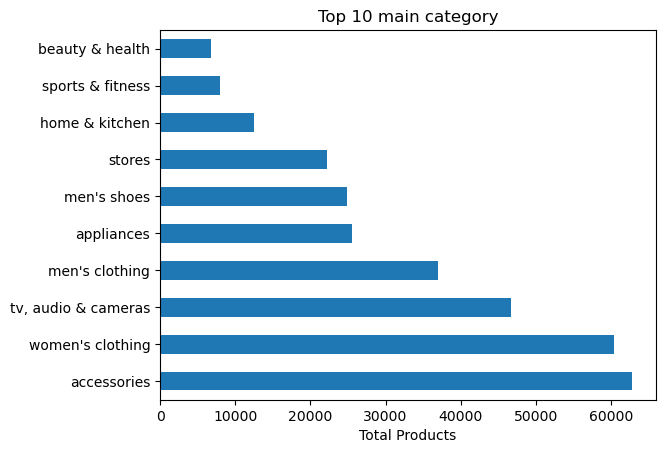

```python
ax = amazon_df['main_category'].value_counts() \
    .head(10) \
    .plot(kind= 'barh', title='Top 10 main category')
ax.set_xlabel('Total Products')
```

Now I want to see which sub category in accessories have the most product

```python
acc_df = amazon_df[amazon_df['main_category'] == 'accessories']
```

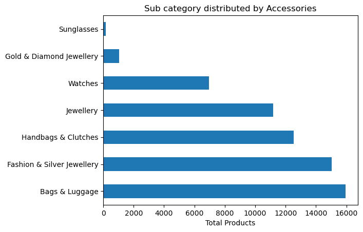

```python
acc_bar = acc_df['sub_category'].value_counts() \
     .plot(kind = 'barh', title='Sub category distributed by Accessories')
acc_bar.set_xlabel('Total Products')
plt.show()
```

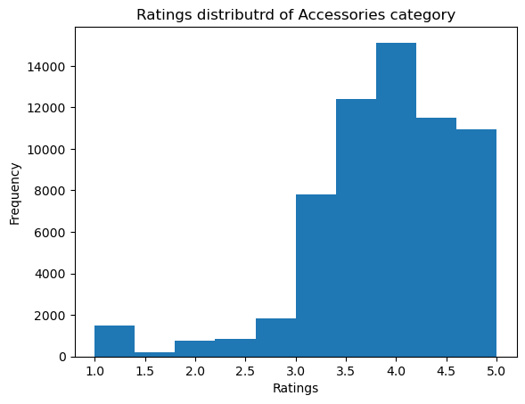

```python
acc_hist = acc_df['ratings'].plot(kind='hist',
                                  bins=10,
                                  title='Ratings distributrd of Accessories category')
acc_hist.set_xlabel('Ratings')
plt.show()
```

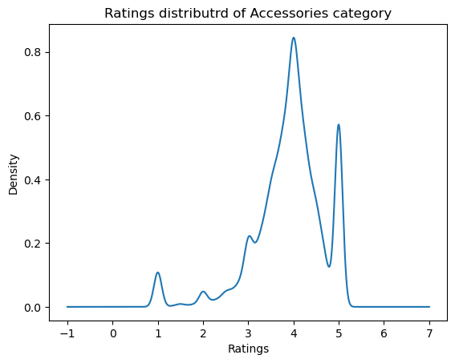

```python
acc_hist = acc_df['ratings'].plot(kind='kde',
                                  title='Ratings distributrd of Accessories category')
acc_hist.set_xlabel('Ratings')
plt.show()
```

```python
rating_df = amazon_df.groupby('main_category')[['no_of_ratings']].sum()
```

```python
rating_df.sort_values('no_of_ratings', ascending=False)
```

| main_category | no_of_ratings |
| --- | --- |
| tv, audio & cameras | 178329604 |
| stores | 17913789 |
| appliances | 16579049 |
| women's clothing | 13216389 |
| toys & baby products | 12439096 |
| accessories | 10465276 |
| beauty & health | 9246838 |
| home & kitchen | 8854606 |
| men's shoes | 4778683 |
| men's clothing | 3899554 |
| sports & fitness | 2592698 |
| grocery & gourmet foods | 1384302 |
| car & motorbike | 1363086 |
| kids' fashion | 1331624 |
| bags & luggage | 1170099 |
| industrial supplies | 917570 |
| pet supplies | 847066 |
| women's shoes | 456452 |
| music | 227200 |
| home, kitchen, pets | 47 |

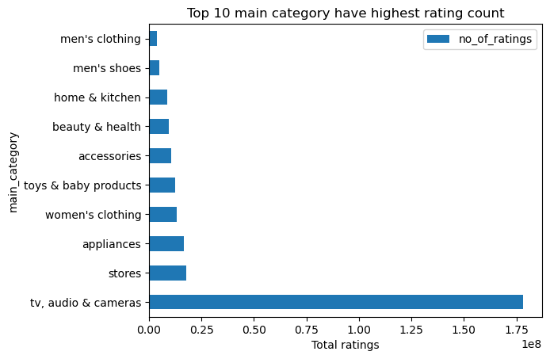

```python
ratings = rating_df.sort_values('no_of_ratings', ascending=False) \
    .head(10) \
    .plot(kind='barh', title='Top 10 main category have highest rating count')
ratings.set_xlabel('Total ratings')
plt.show()
```

## 4. Freature relationship

```python
amazon_df
```

|  | name | main_category | sub_category | image | link | ratings | no_of_ratings | discount_price | actual_price | total_discount | discount_percented |
| --- | --- | --- | --- | --- | --- | --- | --- | --- | --- | --- | --- |
| 0 | Lloyd 1.5 Ton 3 Star Inverter Split Ac (5 In 1... | appliances | Air Conditioners | https://m.media-amazon.com/images/I/31UISB90sY... | https://www.amazon.in/Lloyd-Inverter-Convertib... | 4.2 | 2255 | 395.988 | 707.880 | 311.892 | 44.060010 |
| 1 | LG 1.5 Ton 5 Star AI DUAL Inverter Split AC (C... | appliances | Air Conditioners | https://m.media-amazon.com/images/I/51JFb7FctD... | https://www.amazon.in/LG-Convertible-Anti-Viru... | 4.2 | 2948 | 557.880 | 911.880 | 354.000 | 38.820897 |
| 2 | LG 1 Ton 4 Star Ai Dual Inverter Split Ac (Cop... | appliances | Air Conditioners | https://m.media-amazon.com/images/I/51JFb7FctD... | https://www.amazon.in/LG-Inverter-Convertible-... | 4.2 | 1206 | 413.880 | 743.880 | 330.000 | 44.361994 |
| 3 | LG 1.5 Ton 3 Star AI DUAL Inverter Split AC (C... | appliances | Air Conditioners | https://m.media-amazon.com/images/I/51JFb7FctD... | https://www.amazon.in/LG-Convertible-Anti-Viru... | 4.0 | 69 | 455.880 | 827.880 | 372.000 | 44.934048 |
| 4 | Carrier 1.5 Ton 3 Star Inverter Split AC (Copp... | appliances | Air Conditioners | https://m.media-amazon.com/images/I/41lrtqXPiW... | https://www.amazon.in/Carrier-Inverter-Split-C... | 4.1 | 630 | 413.880 | 813.480 | 399.600 | 49.122289 |
| ... | ... | ... | ... | ... | ... | ... | ... | ... | ... | ... | ... |
| 340675 | BE SAVAGE Pink I Purple You Hoodie Suitable fo... | sports & fitness | Yoga | https://m.media-amazon.com/images/I/61voQ68VuT... | https://www.amazon.in/Be-savage-Purple-Hoodie-... | 4.6 | 6 | 8.532 | 11.988 | 3.456 | 28.828829 |
| 340676 | Adidas Regular Fit Men's Track Tops | sports & fitness | Yoga | https://m.media-amazon.com/images/I/71tHAR9pIY... | https://www.amazon.in/Adidas-Regular-Mens-Trac... | 3.2 | 9 | 41.388 | 55.188 | 13.800 | 25.005436 |
| 340677 | Redwolf Noice Toit Smort - Hoodie (Black) | sports & fitness | Yoga | https://m.media-amazon.com/images/I/41pKrMZ5lQ... | https://www.amazon.in/Redwolf-Noice-Smort-Cott... | 2.0 | 2 | 14.388 | 23.988 | 9.600 | 40.020010 |
| 340678 | Redwolf Schrute Farms B&B - Hoodie (Navy Blue) | sports & fitness | Yoga | https://m.media-amazon.com/images/I/41n9u+zNSc... | https://www.amazon.in/Redwolf-Schrute-Farms-Ho... | 4.0 | 1 | 14.388 | 23.988 | 9.600 | 40.020010 |
| 340679 | Mothercare Printed Cotton Elastane Girls Infan... | sports & fitness | Yoga | https://m.media-amazon.com/images/I/814X-sI3DB... | https://www.amazon.in/Mothercare-Carrot-Regula... | 4.6 | 5 | 12.468 | 15.588 | 3.120 | 20.015396 |

334963 rows × 11 columns

```python
df_corr = amazon_df[['ratings',
                     'no_of_ratings',
                     'discount_price',
                     'actual_price',
                     'total_discount',
                     'discount_percented']].corr()
df_corr
```

|  | ratings | no_of_ratings | discount_price | actual_price | total_discount | discount_percented |
| --- | --- | --- | --- | --- | --- | --- |
| ratings | 1.000000 | 0.040749 | 0.057262 | -0.004137 | -0.004159 | -0.095584 |
| no_of_ratings | 0.040749 | 1.000000 | 0.010138 | -0.000159 | -0.000163 | -0.013608 |
| discount_price | 0.057262 | 0.010138 | 1.000000 | 0.000196 | -0.000178 | -0.185260 |
| actual_price | -0.004137 | -0.000159 | 0.000196 | 1.000000 | 1.000000 | 0.003926 |
| total_discount | -0.004159 | -0.000163 | -0.000178 | 1.000000 | 1.000000 | 0.003995 |
| discount_percented | -0.095584 | -0.013608 | -0.185260 | 0.003926 | 0.003995 | 1.000000 |

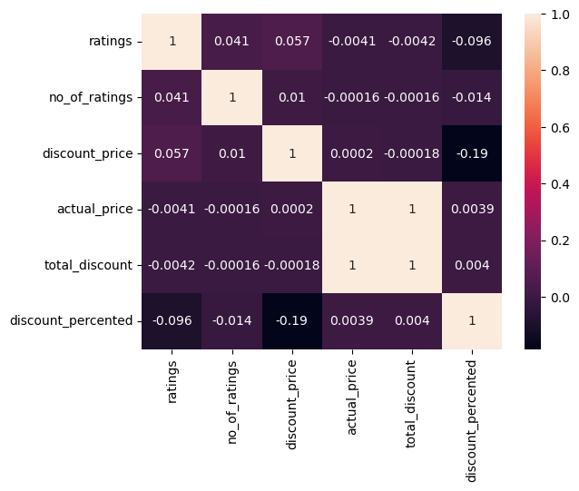

```python
sns.heatmap(df_corr, annot=True)
```

## 5. Ask question about the data

### a. Top main category have the highest average price?

```python
ax = amazon_df.groupby('main_category')['actual_price'] \
    .agg(['mean','count']) \
    .sort_values('count', ascending=False) \
    .query('count > 5000') \
    .sort_values('mean', ascending=False)
ax
```

| main_category | mean | count |
| --- | --- | --- |
| home & kitchen | 9507.929641 | 12524 |
| sports & fitness | 125.920512 | 8028 |
| appliances | 90.792884 | 25547 |
| tv, audio & cameras | 72.812273 | 46756 |
| men's shoes | 40.294333 | 24833 |
| accessories | 36.915663 | 62869 |
| stores | 30.325184 | 22191 |
| women's clothing | 21.629979 | 60447 |
| car & motorbike | 21.549685 | 5156 |
| men's clothing | 20.129447 | 37025 |
| kids' fashion | 18.838114 | 5698 |
| beauty & health | 12.331577 | 6723 |

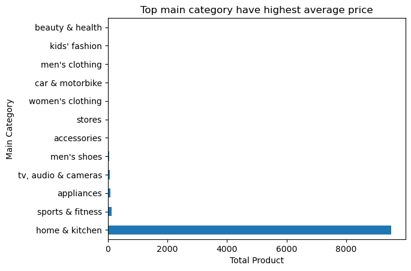

```python
ax['mean'].plot(kind='barh',
        title='Top main category have highest average price',
        xlabel='Total Product',
        ylabel='Main Category')
plt.show()
```

We can see Home & Kitchen have way higher average price.

```python
amazon_df[amazon_df['main_category'] == 'home & kitchen'].sort_values('actual_price', ascending=False)
```

|  | name | main_category | sub_category | image | link | ratings | no_of_ratings | discount_price | actual_price | total_discount | discount_percented |
| --- | --- | --- | --- | --- | --- | --- | --- | --- | --- | --- | --- |
| 141117 | Marutivilla Insect Killer, Mosquito Killer Lig... | home & kitchen | Garden & Outdoors | https://m.media-amazon.com/images/W/IMAGERENDE... | https://www.amazon.in/Marutivilla-Mosquito-Suc... | 2.0 | 1 | 7.068 | 1.188000e+08 | 1.188000e+08 | 99.999994 |
| 140023 | The Sleep Company Elev8 Smart Adjustable Bed \|... | home & kitchen | Furniture | https://m.media-amazon.com/images/I/71RDb5miWW... | https://www.amazon.in/Sleep-Company-Elev8-Smar... | 4.2 | 56 | 719.988 | 1.200000e+03 | 4.800120e+02 | 40.001000 |
| 140120 | Fabrique Visionary 3+2+1 Leatherette 6 Seater ... | home & kitchen | Furniture | https://m.media-amazon.com/images/W/IMAGERENDE... | https://www.amazon.in/Fabrique-Visionary-Leath... | 4.2 | 9 | 726.000 | 1.044000e+03 | 3.180000e+02 | 30.459770 |
| 139720 | DEVKI INTERIORS Crafter Sheesham Wood King Siz... | home & kitchen | Furniture | https://m.media-amazon.com/images/W/IMAGERENDE... | https://www.amazon.in/DEVKI-INTERIORS-Crafter-... | 4.3 | 24 | 277.560 | 9.749520e+02 | 6.973920e+02 | 71.530906 |
| 21163 | Carrier 1.5 Ton 5 Star AI Flexicool Inverter S... | home & kitchen | All Home & Kitchen | https://m.media-amazon.com/images/I/61JtwWcAco... | https://www.amazon.in/Carrier-Flexicool-Conver... | 4.0 | 568 | 503.988 | 9.418800e+02 | 4.378920e+02 | 46.491273 |
| ... | ... | ... | ... | ... | ... | ... | ... | ... | ... | ... | ... |
| 267029 | Nataraj 621 Sharpeners - Pack of 20 | home & kitchen | Sewing & Craft Supplies | https://m.media-amazon.com/images/I/61+6u6QMxf... | https://www.amazon.in/Nataraj-621-Sharpeners-P... | 4.3 | 144 | 0.480 | 7.200000e-01 | 2.400000e-01 | 33.333333 |
| 267463 | Fevicol MR Easy Flow Squeeze Bottle, 105g | home & kitchen | Sewing & Craft Supplies | https://m.media-amazon.com/images/W/IMAGERENDE... | https://www.amazon.in/Fevicol-Easy-Flow-Squeez... | 4.2 | 165 | 0.660 | 7.200000e-01 | 6.000000e-02 | 8.333333 |
| 181133 | STANLEY 62-257 Phillips® Screwdriver-PH0X100mm | home & kitchen | Home Improvement | https://m.media-amazon.com/images/I/61SLIsC6Xc... | https://www.amazon.in/Stanley-62-257-STANLEY-P... | 4.1 | 549 | 0.564 | 5.880000e-01 | 2.400000e-02 | 4.081633 |
| 21500 | Nescafe Ready to Drink Coffee - Hazelnut, 180ml | home & kitchen | All Home & Kitchen | https://m.media-amazon.com/images/W/IMAGERENDE... | https://www.amazon.in/NESCAF%C3%89-Ready-Drink... | 4.2 | 696 | 0.516 | 5.400000e-01 | 2.400000e-02 | 4.444444 |
| 140993 | ballatha 550 GSM, Grow Bags for Terrace Garden... | home & kitchen | Garden & Outdoors | https://m.media-amazon.com/images/I/51e5+9O1It... | https://www.amazon.in/ballatha-Grow-Terrace-Ga... | 4.0 | 1 | 0.300 | 3.600000e-01 | 6.000000e-02 | 16.666667 |

12524 rows × 11 columns

The Home & kitchen category have 1 unsual product which discount percented is 99.99%. So I gonna exclude that main category to make the data more reliable.

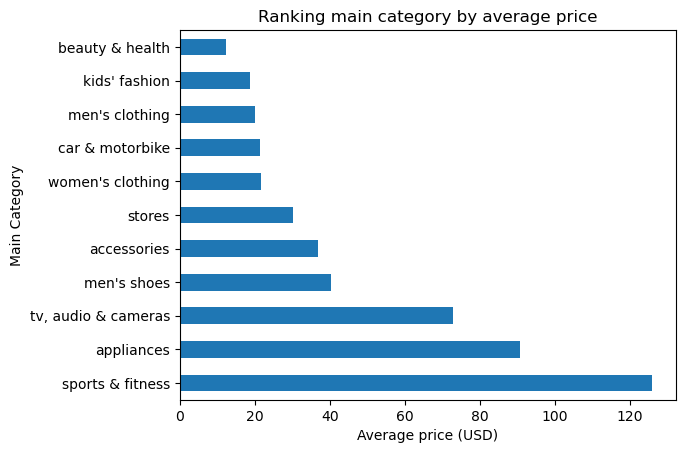

```python
ax= amazon_df.query('main_category != "home & kitchen"') \
    .groupby('main_category')['actual_price'] \
    .agg(['mean','count']) \
    .query('count > 5000') \
    .sort_values('mean', ascending=False)['mean'] \
    .plot(kind='barh', title='Ranking main category by average price')
ax.set_xlabel('Average price (USD)')
ax.set_ylabel('Main Category')
plt.show()
```

## 6. Sumarize and Conclusion

This dataset contain total 142 difference categories. After investigate into this dataset, we can learn many things.

1. `Accessories` is the main category which has most products in Amazon, most ratings is at 4.0, and average price is approximate 37 USD.
2. `Home & kitchen` has the highest average price at 9500 USD, which has 1 unsual product have 99.99% discount.